# Association and effects

Practical workbooks

Author

Javier Álvarez Liébana

```r
library(tidyverse)
```

# 1 Cuali vs cuali

## 1.1 🐣 Case study I: dataviz with the patient satisfaction survey

We will continue practising with the `SatisfaccionPacientes.csv` dataset, also using it to work with factors.

```r
library(readr) # dentro de tidyverse
# en mi caso tengo el .csv en una carpeta datos dentro del proyecto
datos <-
  read_csv(file = "./data/SatisfaccionPacientes.csv") |>
  # la función clean_names del paquete janitor
  # nos normaliza nombres de variables
  janitor::clean_names() |>
  mutate(estado_civil = factor(estado_civil),
         genero = factor(genero))
datos
```

```
# A tibble: 100 × 8
      id  edad genero    estado_civil tiempo_espera grado_satisfaccion
   <dbl> <dbl> <fct>     <fct>                <dbl>              <dbl>
 1     1    60 Masculino Casado                  28                  8
 2     2    44 Femenino  Soltero                 22                  8
 3     3    43 Masculino Soltero                  8                  9
 4     4    32 Masculino Soltero                 21                  8
 5     5    66 Masculino Divorciado               7                 10
 6     6    43 Masculino Divorciado              20                  8
 7     7    54 Masculino Casado                  18                  6
 8     8    55 Masculino Soltero                 29                  6
 9     9    56 Masculino Viudo                   17                  9
10    10    34 Femenino  Casado                  34                  8
# ℹ 90 more rows
# ℹ 2 more variables: numero_visitas <dbl>, estado_salud <chr>
```

### 1.1.1 Question 1

> Convert the `estado_salud` variable appropriately to an ORDINAL qualitative variable.

```r
datos <-
  datos |>
  mutate(estado_salud =
           factor(estado_salud, levels = c("Malo", "Regular", "Bueno", "Excelente"),
                  ordered = TRUE))
```

### 1.1.2 Question 2

> Use `table()` to calculate the frequency table of `genero` and `estado_civil`.

```r
table(datos$genero)
table(datos$estado_civil)
```

[output not shown]

### 1.1.3 Question 3

> One of the categories is completely negligible (only 1 Excelente). It would be advisable to recategorise it: whenever Excelente is detected, it should be recoded as Bueno (general rule: categories should contain at least 5% of all individuals in the sample). Hint: use mutate and if_else.

```r
datos <-
  datos |>
  mutate(estado_salud  = if_else(estado_salud  == "Excelente", "Bueno", estado_salud),
         # ojo: hay que redefinir los niveles de la cualitativa
         # ya que ha dejado de ser factor (veremos un día el paquete forcats para esto)
         estado_salud =
           factor(estado_salud, levels = c("Malo", "Regular", "Bueno"),
                  ordered = TRUE))
```

### 1.1.4 Question 4

> Calculate the mean, median, interquartile range and standard deviation of the satisfaction score disaggregated by gender.

```r
resumen <-
  datos |>
  summarise(media_grado_satisfaccion = mean(grado_satisfaccion),
           sd_grado_satisfaccion = sd(grado_satisfaccion),
           mediana_grado_satisfaccion = median(grado_satisfaccion),
           IQR_grado_satisfaccion =
             quantile(grado_satisfaccion, probs = 0.75) -
             quantile(grado_satisfaccion, probs = 0.25),
           .by = genero)
```

### 1.1.5 Question 5

> Export the previous results (`resumen`) to a `resumen.csv` file. Instead of `read_csv()`, use `write_csv(table, file = "path")`.

```r
# importado como csv
write_csv(resumen, file = "./resumen.csv")
```

### 1.1.6 Question 6

> Create a bar chart for the gender variable.

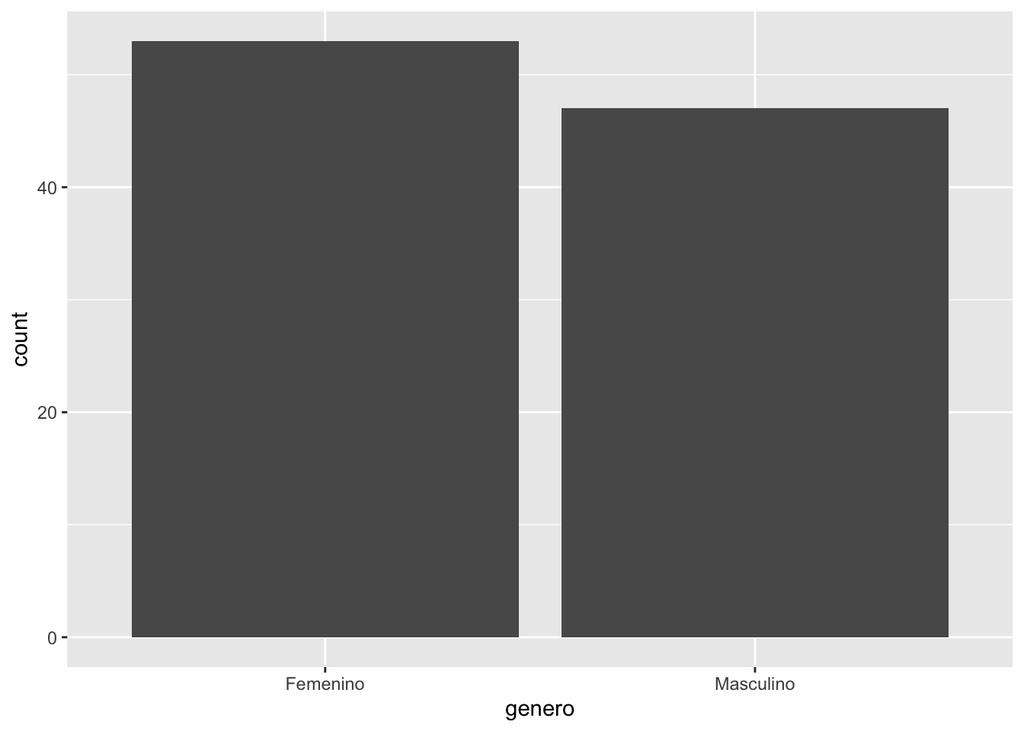

```r
# Género: fíjate que por defecto `geom_bar()` cuenta y visualiza ese conteo `n`.
ggplot(datos) +
  geom_bar(aes(x = genero))
```

### 1.1.7 Question 7

> How could we make each bar (i.e., for each gender category) have its own fill colour?

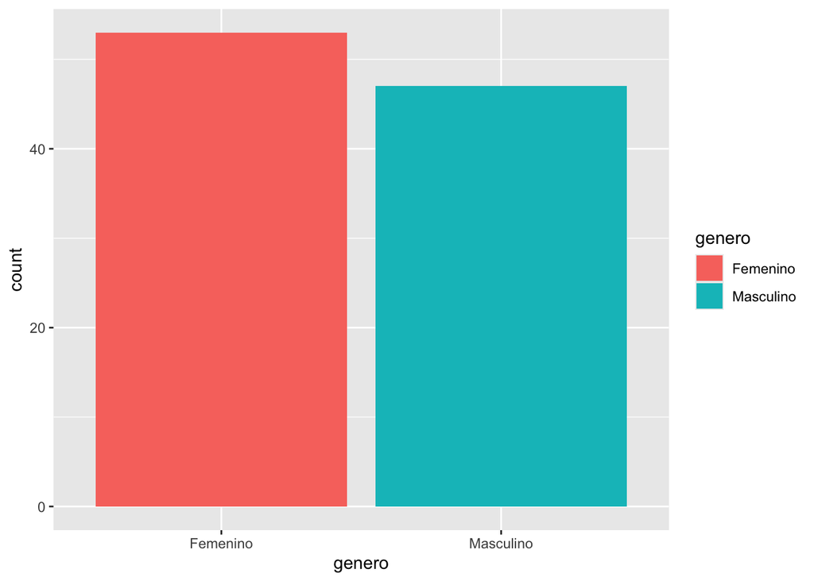

```r
ggplot(datos) +
  # dentro de aes() para que dependa de la tabla
  geom_bar(aes(x = genero, fill = genero))
```

### 1.1.8 Question 8

> In a chart we can use not only colour as an aesthetic parameter but also play with transparency (the `alpha` parameter). Modify the previous chart to make the colours slightly more transparent.

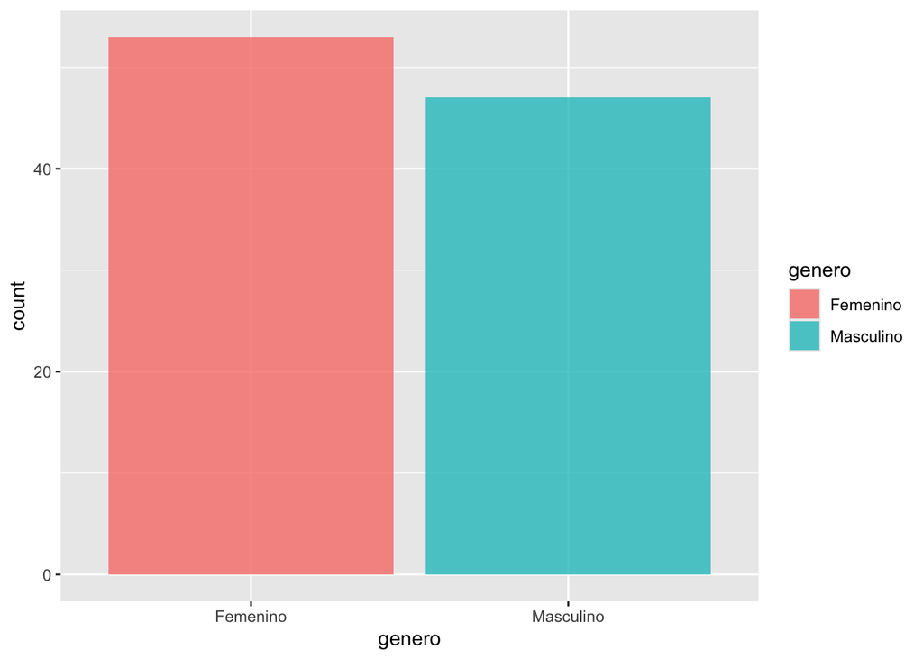

```r
ggplot(datos) +
  geom_bar(aes(x = genero, fill = genero), alpha = 0.75)
```

### 1.1.9 Question 9

> A very important layer in ggplot is `labs()`. Add axis labels, legend title, chart title, subtitle and caption.

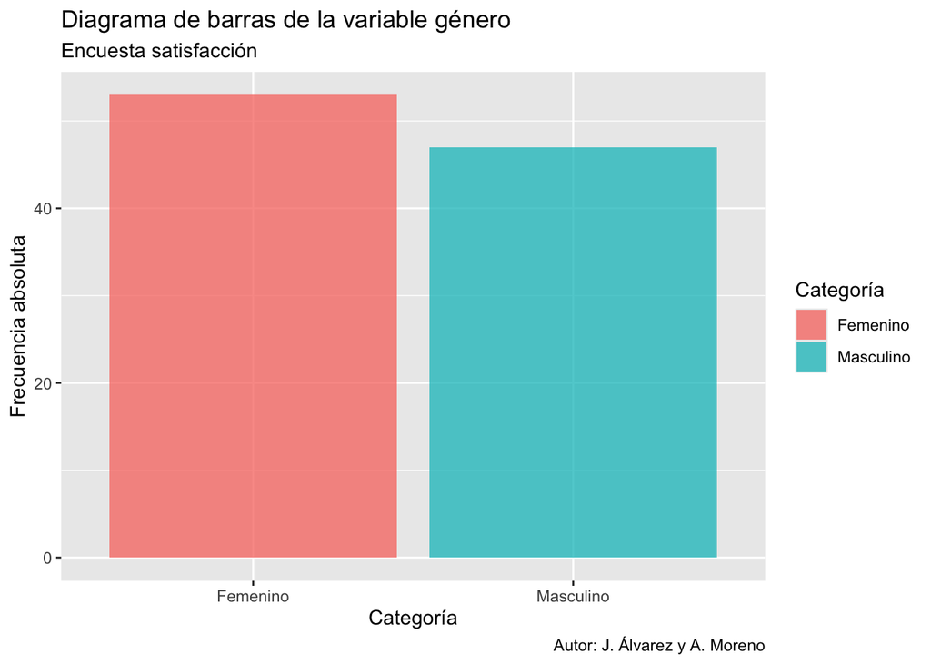

```r
ggplot(datos) +
  geom_bar(aes(x = genero, fill = genero), alpha = 0.75) +
  labs(title = "Diagrama de barras de la variable género",
       subtitle = "Encuesta satisfacción",
       caption = "Autor: J. Álvarez y A. Moreno",
       x = "Categoría", y = "Frecuencia absoluta", fill = "Categoría")
```

### 1.1.10 Question 10

> We can also add a theme layer: a set of predefined settings (font, size, background colours, etc.). The most minimalist but clean one is `theme_minimal()`.

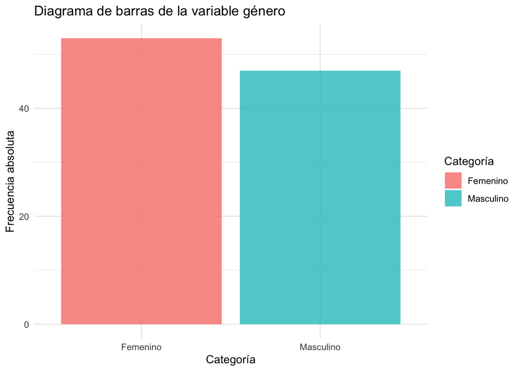

```r
ggplot(datos) +
  geom_bar(aes(x = genero, fill = genero), alpha = 0.75) +
  labs(title = "Diagrama de barras de la variable género",
       x = "Categoría", y = "Frecuencia absoluta",
       fill = "Categoría") +
  theme_minimal()
```

You can find more themes in the `{ggthemes}` package.

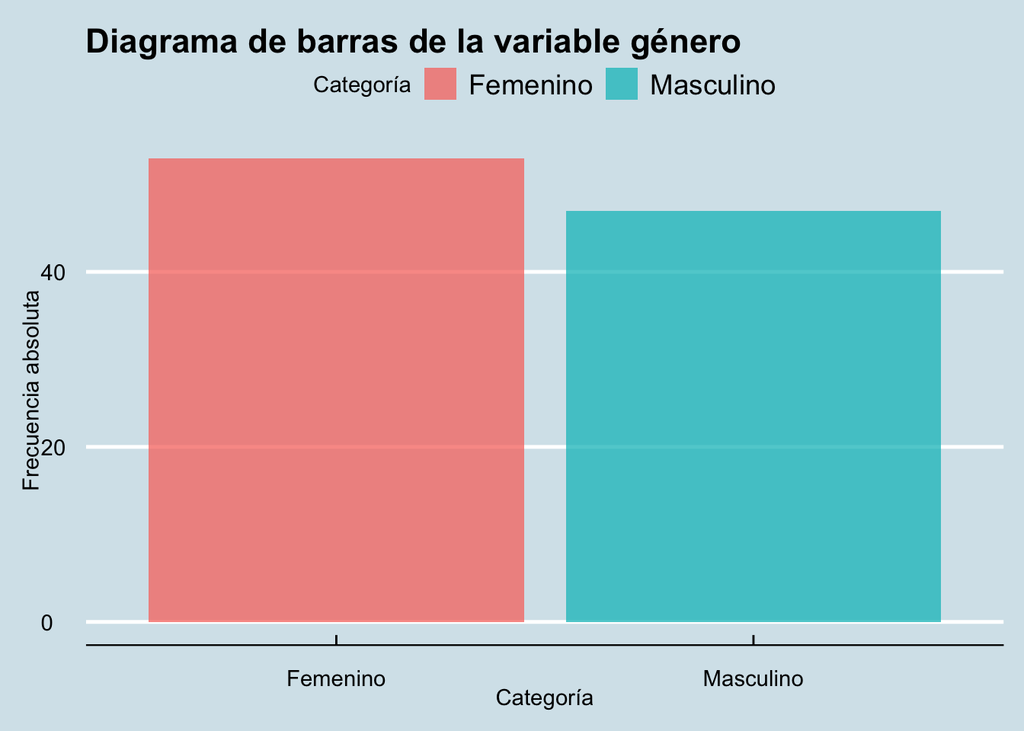

```r
ggplot(datos) +
  geom_bar(aes(x = genero, fill = genero), alpha = 0.75) +
  labs(title = "Diagrama de barras de la variable género",
       x = "Categoría", y = "Frecuencia absoluta",
       fill = "Categoría") +
  ggthemes::theme_economist()
```

> Now redo the previous chart choosing your own colours for each gender category and applying a theme.

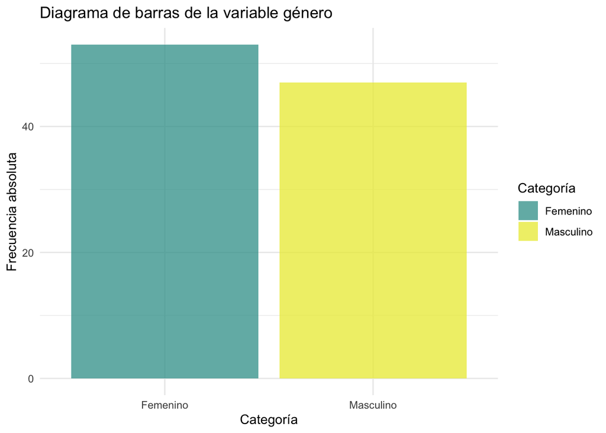

```r
ggplot(datos) +
  geom_bar(aes(x = genero, fill = genero), alpha = 0.75) +
  # reminder: el relleno es fill, color para el reborde si quieres
  scale_fill_manual(values = c("#379e98", "#eaea3e")) +
  labs(title = "Diagrama de barras de la variable género",
       x = "Categoría", y = "Frecuencia absoluta",
       fill = "Categoría") +
 theme_minimal()
```

The `{ggthemes}` package also includes ready-made palettes, for example one designed for colour-blind users: `scale_fill_colorblind()`.

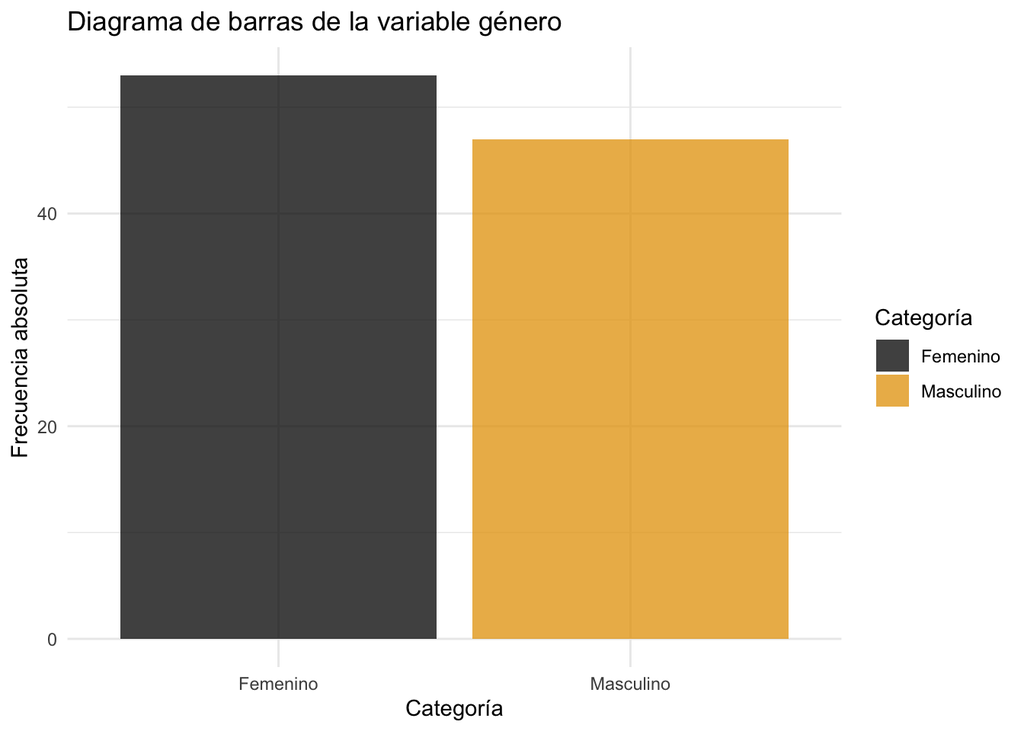

```r
ggplot(datos) +
  geom_bar(aes(x = genero, fill = genero), alpha = 0.75) +
  ggthemes::scale_fill_colorblind() +
  labs(title = "Diagrama de barras de la variable género",
       x = "Categoría", y = "Frecuencia absoluta",
       fill = "Categoría") +
 theme_minimal()
```

### 1.1.11 Question 11

> Create from scratch a bar chart — with the customisations seen in previous exercises — for the health status variable.

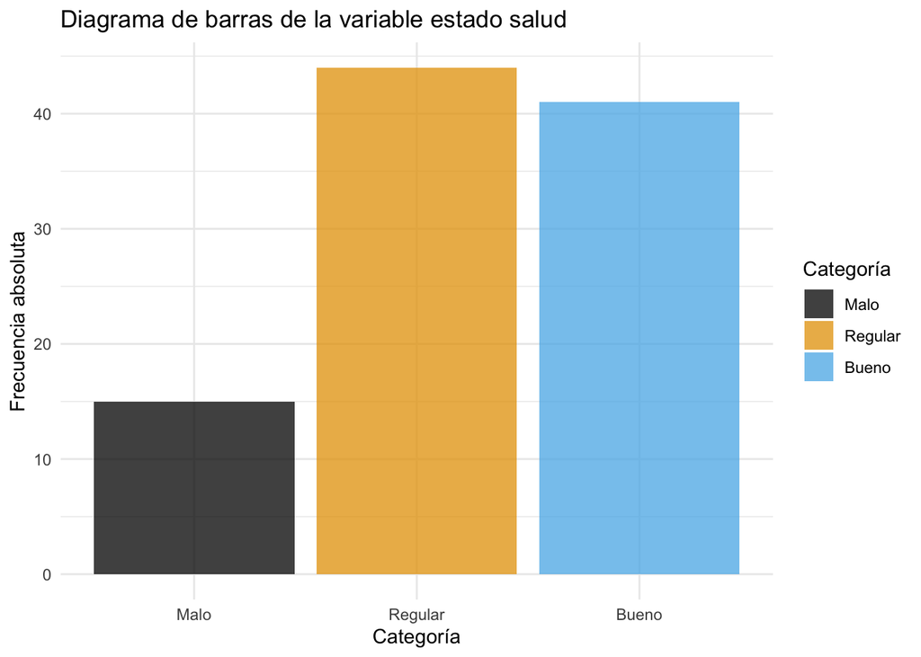

```r
# Estado de salud (ahora el orden importa)
ggplot(datos) +
  geom_bar(aes(x = estado_salud, fill = estado_salud), alpha = 0.75) +
  ggthemes::scale_fill_colorblind() +
  labs(title = "Diagrama de barras de la variable estado salud",
       x = "Categoría",  y = "Frecuencia absoluta",
       fill = "Categoría") +
  theme_minimal()
```

Notice that if **the variable were not defined as an ordinal qualitative, the bars would follow alphabetical order**, not the actual hierarchy.

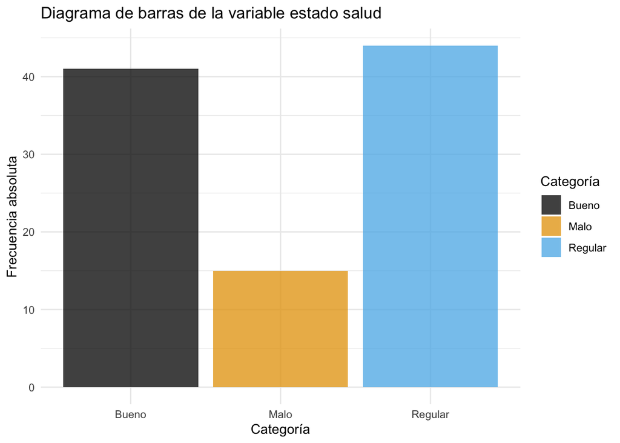

```r
ggplot(datos) +
  geom_bar(aes(x = as.character(estado_salud), fill = as.character(estado_salud)),
           alpha = 0.75) +
  ggthemes::scale_fill_colorblind() +
  labs(title = "Diagrama de barras de la variable estado salud",
       x = "Categoría",  y = "Frecuencia absoluta",
       fill = "Categoría") +
  theme_minimal()
```

### 1.1.12 Question 12

> Create the histogram shown below for the variables `edad` and `tiempo_espera`.

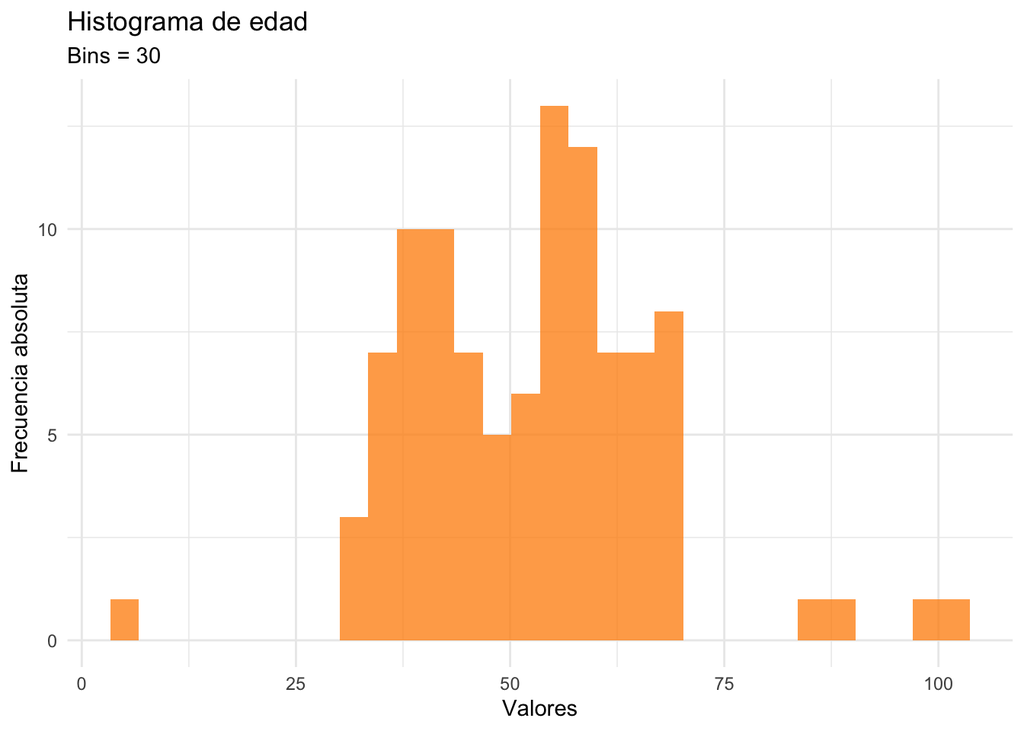

```r
ggplot(datos) +
  geom_histogram(aes(x = edad), bins = 30, fill = "darkorange", alpha = 0.75) +
  labs(title = "Histograma de edad", subtitle = "Bins = 30",
       x = "Valores", y = "Frecuencia absoluta") +
  theme_minimal()
```

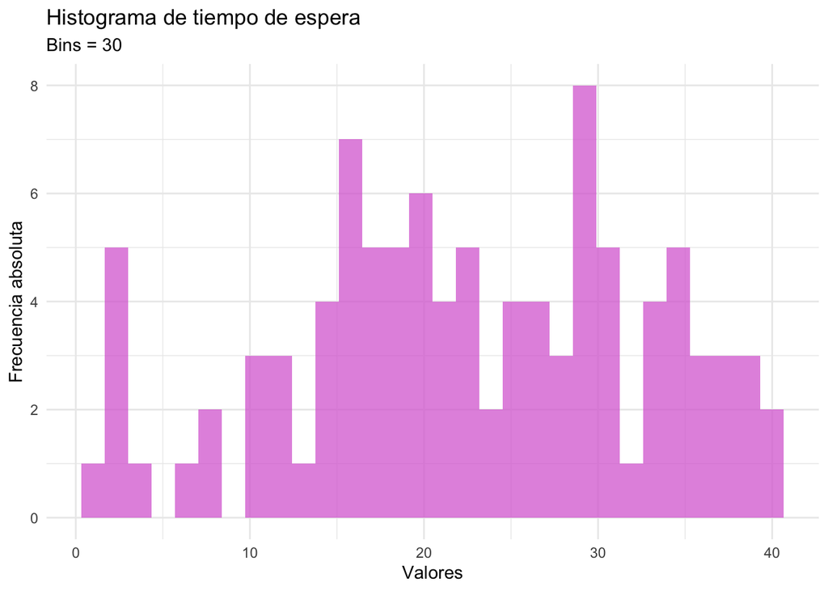

```r
ggplot(datos) +
  # Define el ancho de las barras y colores
  geom_histogram(aes(x = tiempo_espera), bins = 30, fill = "orchid", alpha = 0.75) +
  labs(title = "Histograma de tiempo de espera", subtitle = "Bins = 30",
       x = "Valores", y = "Frecuencia absoluta") +
  theme_minimal()
```

### 1.1.13 Question 13

> Create the density plot shown below for the variables `edad` and `tiempo_espera`.

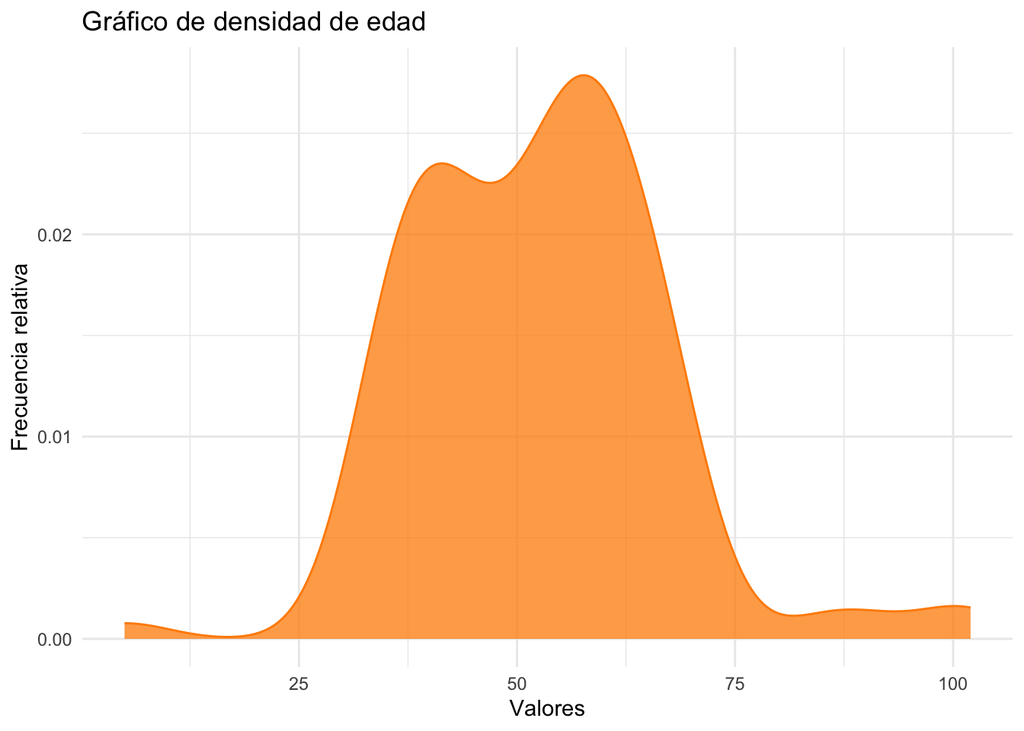

```r
ggplot(datos) +
  geom_density(aes(x = edad), color = "darkorange",
               fill = "darkorange", alpha = 0.75) +
  labs(title = "Gráfico de densidad de edad",
       x = "Valores", y = "Frecuencia relativa") +
  theme_minimal()
```

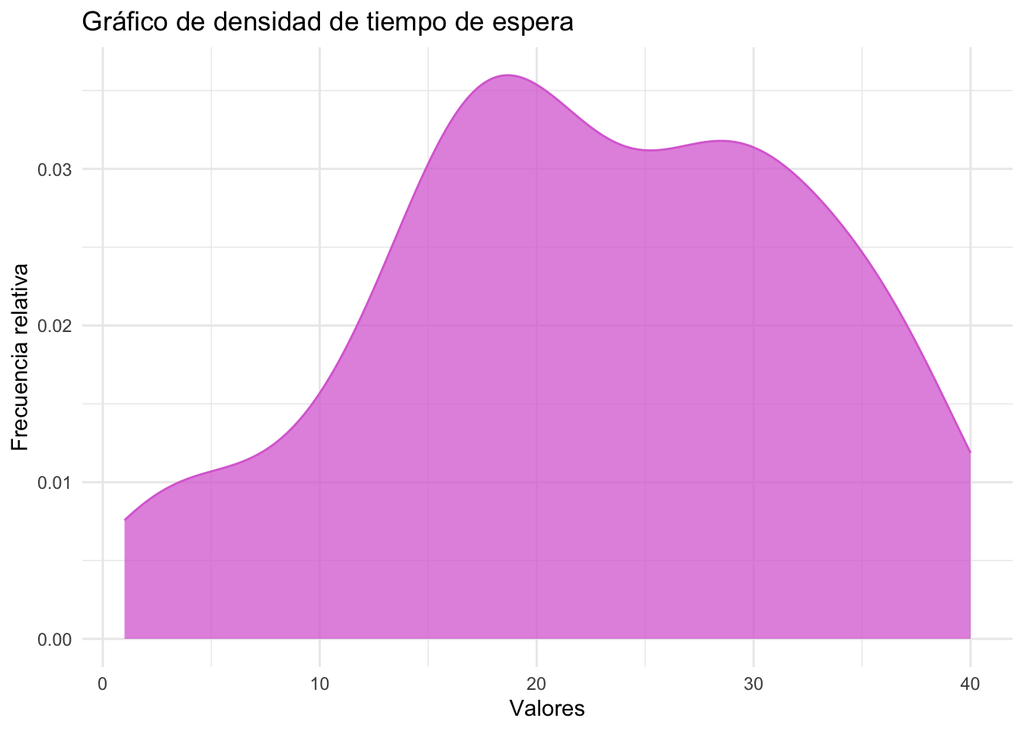

```r
ggplot(datos) +
  geom_density(aes(x = tiempo_espera), color = "orchid",
               fill = "orchid", alpha = 0.75) +
  labs(title = "Gráfico de densidad de tiempo de espera",
       x = "Valores", y = "Frecuencia relativa") +
  theme_minimal()
```

### 1.1.14 Question 14

> Create a boxplot for `edad` and a boxplot for waiting time BY gender (two variables — think about how to do it).

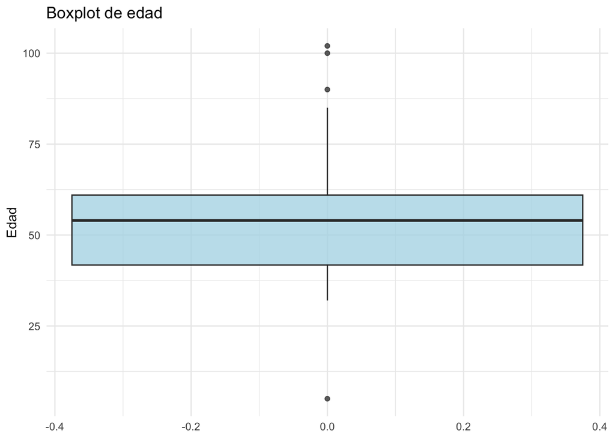

```r
ggplot(datos) +
  geom_boxplot(aes(y = edad), fill = "lightblue", alpha = 0.75) +
  labs(title = "Boxplot de edad",  y = "Edad") +
  theme_minimal()
```

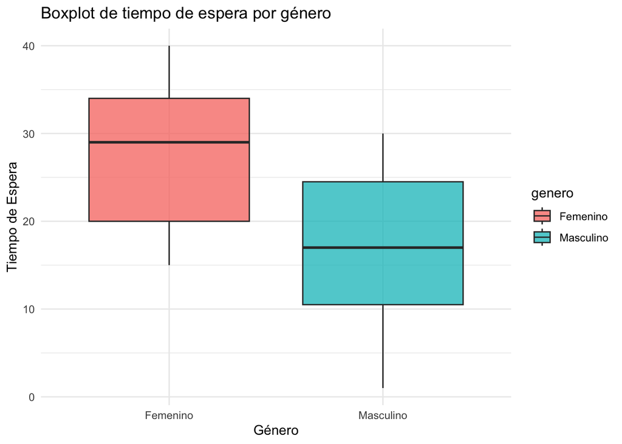

```r
ggplot(datos) +
  geom_boxplot(aes(x = genero, y = tiempo_espera, fill = genero),
               alpha = 0.75) +
  labs(title = "Boxplot de tiempo de espera por género",
       x = "Género", y = "Tiempo de Espera") +
  theme_minimal()
```

> Using the previous chart:
1. Does the `edad` variable have outliers? How old are those patients?
2. Who waited longer, men or women?

In boxplots we can also **specify custom parameters for the outliers**.

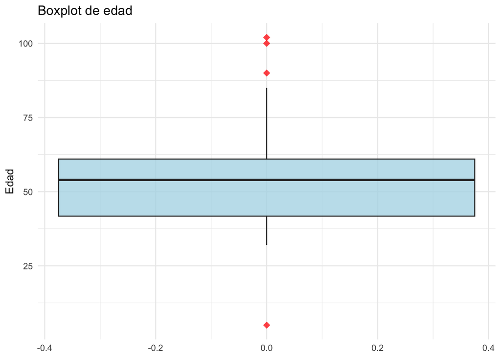

```r
ggplot(datos) +
  geom_boxplot(aes(y = edad), fill = "lightblue", alpha = 0.75,
               outlier.colour = "red", outlier.shape = 18, outlier.size = 3) +
  labs(title = "Boxplot de edad",  y = "Edad") +
  theme_minimal()
```